# Composite Variables: Introduction and PCA

## Resources

- Everitt and Hothorn (2011) *An Introduction to Applied Multivariate Analysis with R*. Springer.
- Tabachnick and Fidell (2013): *Using Multivariate Statistics*. Pearson.

## Motivation: the curse of dimensionality

Multivariate data is not just a challenge for visualization.

You have too many variables

- Some are redundant in measuring essentially the same thing
- Some are highly correlated with others (multicollinear)
- Some are both

Your number of variables approaches your number of observations.

## What is a composite variable?

> A linear combination of variables

Multiple Regression Makes a Composite Variable

- Linear combination of predictor variables that is maximally correlated with outcome variable
- \(y = {\beta_1}X_1 + {\beta_2}X_2 + {\beta_3}X_3\)
- \(\hat{y}\) is a composite variable

## Multiple regression makes a composite variable

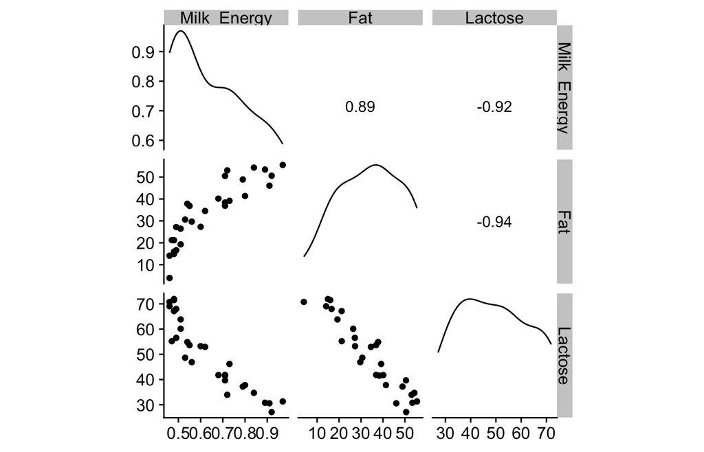

## Milk investment across mammalian species

[interactive chart not shown]

## Principal components analysis

*Goals*:

1. Create a set of composite variables that encompasses the shared variation among variables
2. Reduce the dimensionality of a set of variables: from considering all variables separately to considering fewer composite variables, while
3. Accounting for as much of the original variation as possible in the data set

No predictor or outcome variable. Think of it as a one sided equation.

## Principal components

*Principal components:*

- Sequential linear combinations of the original variables
- The resulting composite variables *are uncorrelated with one another*
- The first few usually account for *most* of the variation in the original data

## Principal components

For *q* variables, you get *q* PCs

- First encompasses the maximum variance
- Each in turn maximizes remaining variance while remaining uncorrelated

## Milk investment

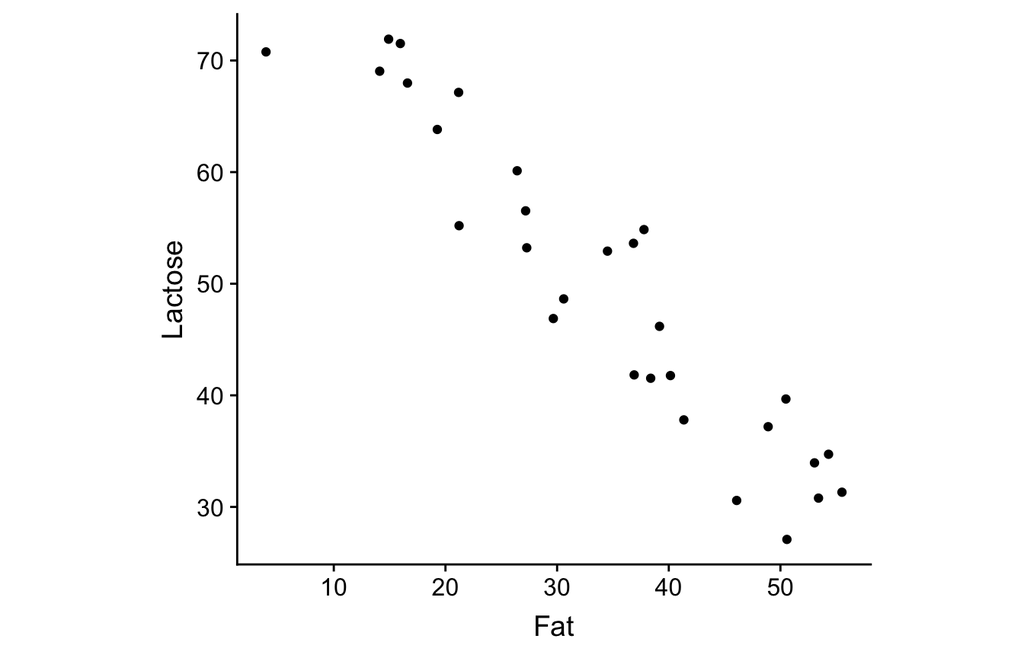

## Milk investment

Find the indices of the minimum and maximum of `x1`

```r
themin <- which.min(M$Fat)
themax <- which.max(M$Fat)
```

Make a `data.frame` with the points for plotting

```r
minpt <- data.frame(x1 = M$Fat[themin], x2 = M$Lactose[themin])
maxpt <- data.frame(x1 = M$Fat[themax], x2 = M$Lactose[themax])
```

## Milk investment

Green = Low Fat, High Lactose

Blue = High Fat, Low Lactose

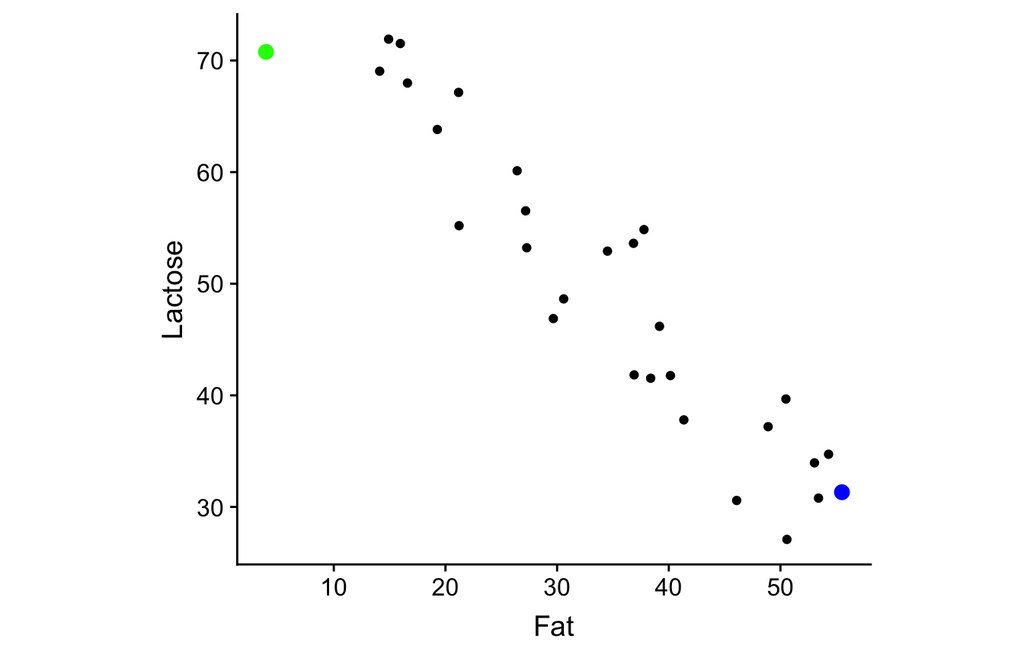

## Major axis == PC1

Green = Low Fat, High Lactose

Blue = High Fat, Low Lactose

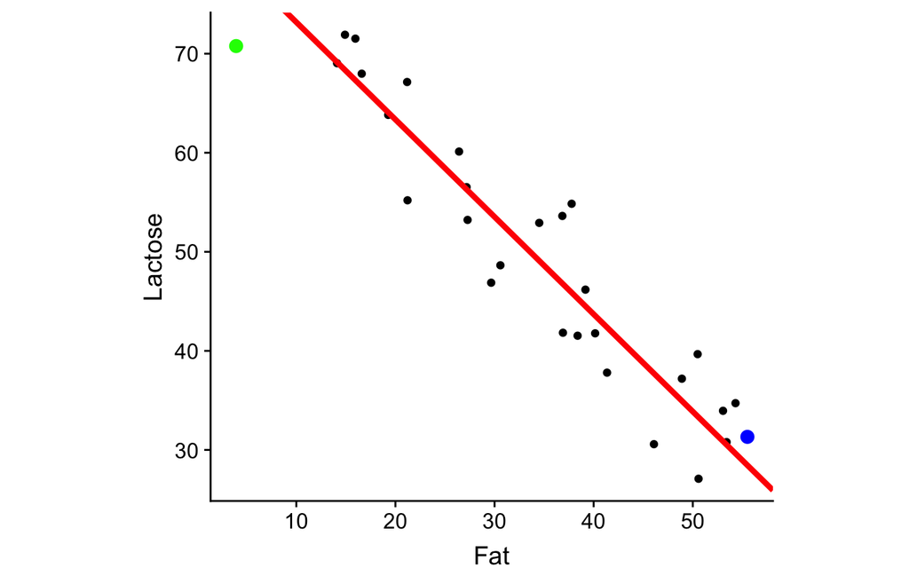

## Minor axis == PC2

Green = Low Fat, High Lactose

Blue = High Fat, Low Lactose

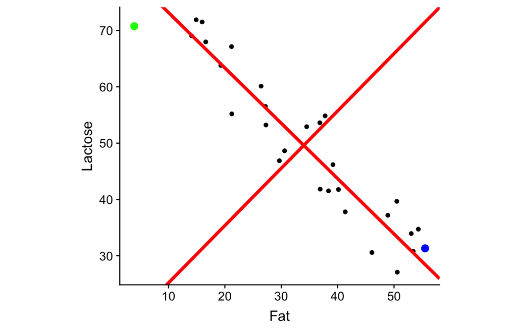

## Plotting PCs

- Rotation of the axes of multivariate data

Green = Low Fat, High Lactose

Blue = High Fat, Low Lactose

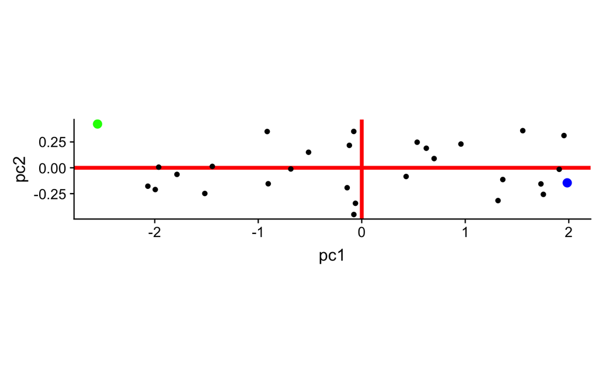

## Comparing PCs

Green = Low Fat, High Lactose

Blue = High Fat, Low Lactose

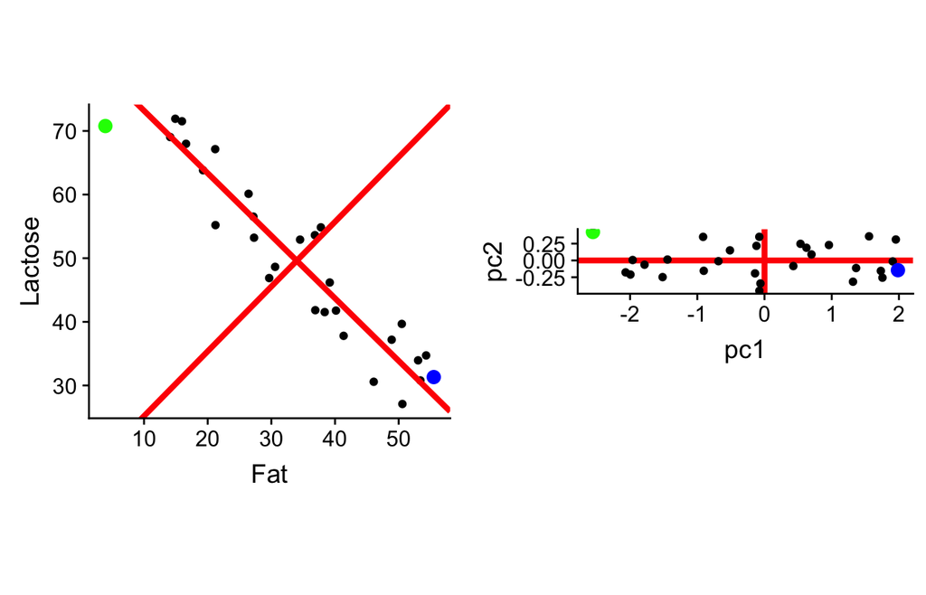

## Principal components

`prcomp()` is the preferred function for PCA (*not* `princomp()`):

```r
z <- prcomp(~ Fat + Lactose, data = M, center = TRUE, scale. = TRUE)
```

- One sided formula: `~ Fat + Lactose`
- Centered to a mean of 0
- Scaled to standard deviation of 1

## More PCA options

Packages:

- `ade4`: https://cran.r-project.org/web/packages/ade4/index.html
- `FactoMineR`: https://cran.r-project.org/web/packages/FactoMineR/index.html

We will use the built-in `prcomp()`.

## `prcomp` objects

```r
str(z)
```

```
## List of 6
##  $ sdev    : num [1:2] 1.393 0.242
##  $ rotation: num [1:2, 1:2] 0.707 -0.707 -0.707 -0.707
##   ..- attr(*, "dimnames")=List of 2
##   .. ..$ : chr [1:2] "Fat" "Lactose"
##   .. ..$ : chr [1:2] "PC1" "PC2"
##  $ center  : Named num [1:2] 34 49.6
##   ..- attr(*, "names")= chr [1:2] "Fat" "Lactose"
##  $ scale   : Named num [1:2] 14.3 14.1
##   ..- attr(*, "names")= chr [1:2] "Fat" "Lactose"
##  $ x       : num [1:29, 1:2] -1.785 -1.444 -1.962 -2.066 -0.514 ...
##   ..- attr(*, "dimnames")=List of 2
##   .. ..$ : chr [1:29] "1" "2" "3" "4" ...
##   .. ..$ : chr [1:2] "PC1" "PC2"
##  $ call    : language prcomp(formula = ~Fat + Lactose, data = M, center = TRUE, scale. = TRUE)
##  - attr(*, "class")= chr "prcomp"
```

`x` is a matrix of the the principal components

## Proportion of variance (eigenvalues)

```r
summary(z)
```

```
## Importance of components:
##                           PC1     PC2
## Standard deviation     1.3934 0.24158
## Proportion of Variance 0.9708 0.02918
## Cumulative Proportion  0.9708 1.00000
```

PC1 explains 97% of the variance in the data.

## Loadings (eigenvectors)

Correlations with with composite variable

```r
print(z)
```

```
## Standard deviations (1, .., p=2):
## [1] 1.3934265 0.2415836
##
## Rotation (n x k) = (2 x 2):
##                PC1        PC2
## Fat      0.7071068 -0.7071068
## Lactose -0.7071068 -0.7071068
```

- `Lactose` loads negatively on PC1 and PC2
- `Fat` loads positively on PC1 and negatively on PC2
- Magnitudes are more informative with more than 2 variables

## Extracting PC scores

```r
PC <- data.frame(pc1 = z$x[, 1],
                 pc2 = z$x[, 2])
PC
```

```
##            pc1          pc2
## 1  -1.78509431 -0.063653225
## 2  -1.44365796  0.013484299
## 3  -1.96166269  0.006259316
## 4  -2.06645523 -0.177723875
## 5  -0.51393051  0.150315276
## 6  -0.91347766  0.350637364
## 7  -0.07717306  0.351480511
## 8   1.90779088 -0.014528235
## 9   1.55556364  0.358828937
## 10  1.95386703  0.311684874
## 11  0.95822267  0.229702746
## 12 -2.55254845  0.423074692
## 13  0.62357110  0.189046494
## 14  0.53522693  0.247205046
## 15  0.42873297 -0.083992416
## 16  0.69910152  0.089367582
## 17  1.73099540 -0.155687913
## 18  1.98506466 -0.145129935
## 19  1.36259231 -0.113289467
## 20  1.75461984 -0.256788764
## 21 -1.99486571 -0.210072095
## 22 -0.14099491 -0.192434707
## 23 -0.90363007 -0.154254327
## 24 -0.07624607 -0.451377680
## 25 -0.68540391 -0.011259289
## 26 -0.11968797  0.216906468
## 27 -1.51615118 -0.248076624
## 28 -0.06089007 -0.342972655
## 29  1.31652081 -0.316752397
```

## Extracting PC scores

Green = Low Fat, High Lactose

Blue = High Fat, Low Lactose

```
##         pc1         pc2
## 1 -1.785094 -0.06365323
```

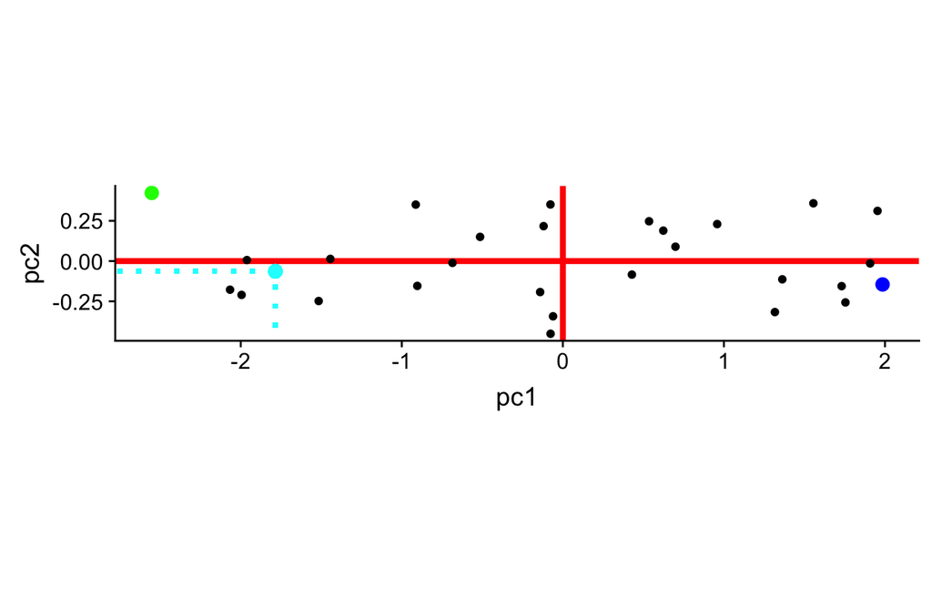

## Visualizing loadings with `biplot()`

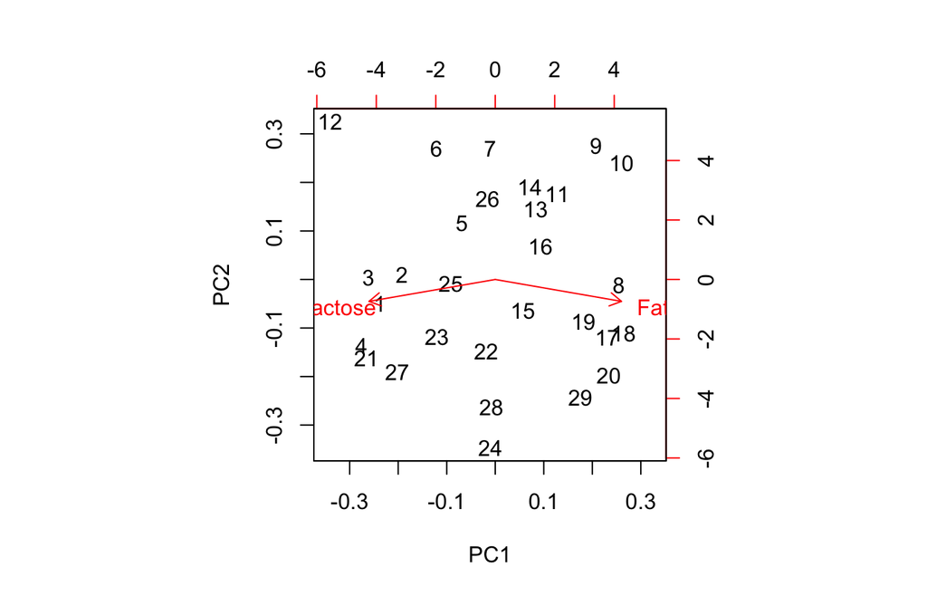

```r
biplot(z)
```

## Use `factoextra` for more handy functions

```r
install.packages("devtools")
library(devtools)
install_github("kassambara/factoextra")
library(factoextra)
```

http://www.sthda.com/english/wiki/factoextra-r-package-quick-multivariate-data-analysis-pca-ca-mca-and-visualization-r-software-and-data-mining

## Extracting eigenvalues

```r
get_eig(z)
```

```
##       eigenvalue variance.percent cumulative.variance.percent
## Dim.1 1.94163735        97.081867                    97.08187
## Dim.2 0.05836265         2.918133                   100.00000
```

Eigenvalues are variances. Default R `print()` method returns standard deviations.

## Screeplot

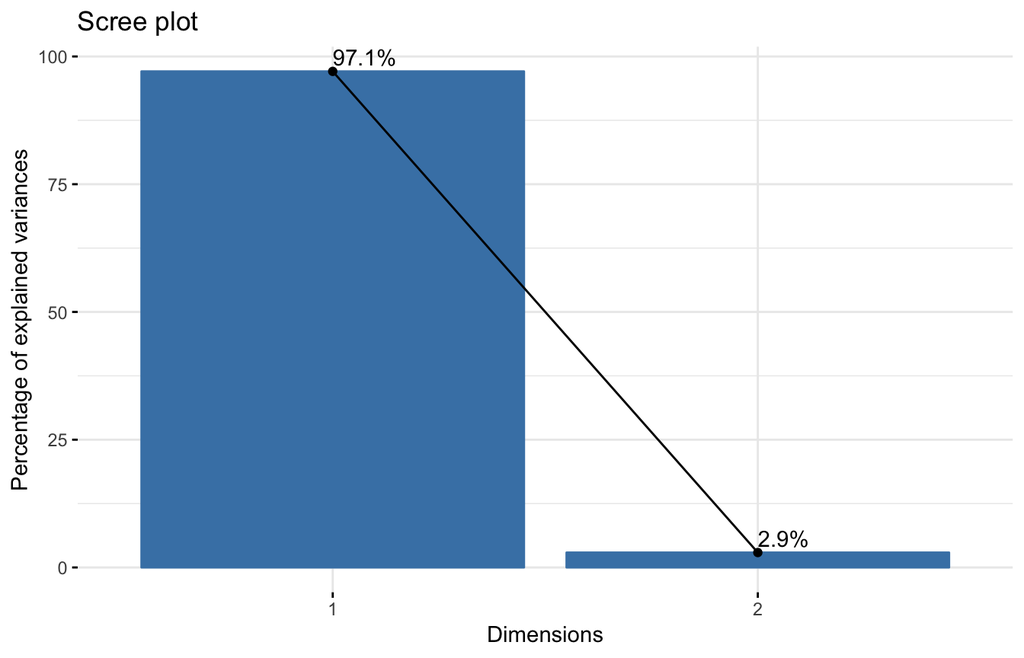

```r
fviz_eig(z, addlabels = TRUE)
```

## Biplot

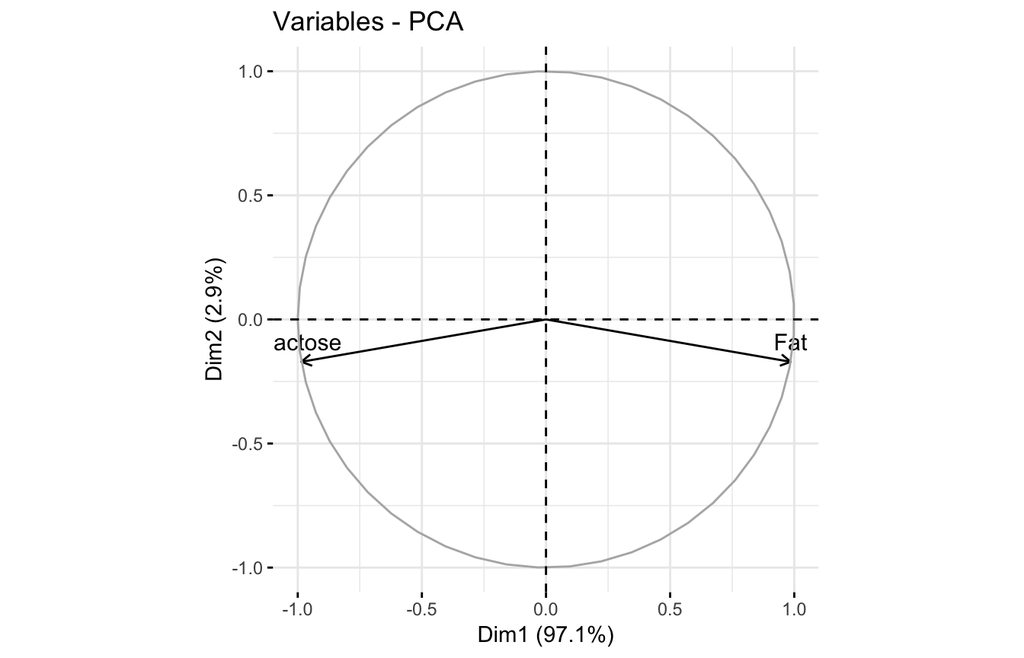

```r
fviz_pca_var(z) + coord_fixed()
```

## Plot of PC scores

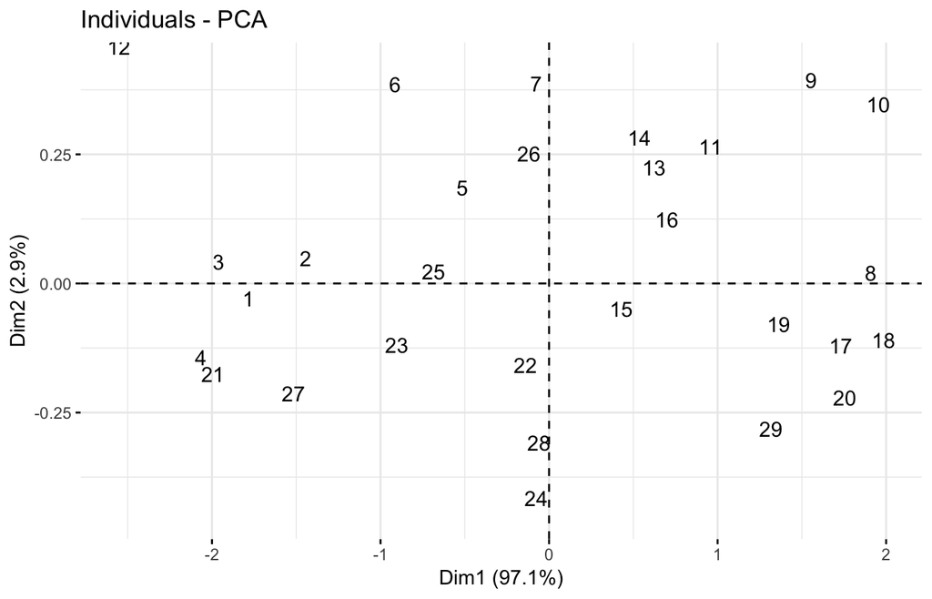

```r
fviz_pca_ind(z, geom = "text")
```

## Milk investment: PCA approach

1. Do fat and lactose together predict milk energy?

```r
PC1 <- z$x[, 1]
summary(lm(Milk_Energy ~ PC1, data = M))
```

```
##
## Call:
## lm(formula = Milk_Energy ~ PC1, data = M)
##
## Residuals:
##      Min       1Q   Median       3Q      Max
## -0.10569 -0.07164  0.01139  0.04552  0.11731
##
## Coefficients:
##             Estimate Std. Error t value Pr(>|t|)
## (Intercept) 0.641724   0.012138   52.87  < 2e-16 ***
## PC1         0.106277   0.008865   11.99 2.54e-12 ***
## ---
## Signif. codes:  0 '***' 0.001 '**' 0.01 '*' 0.05 '.' 0.1 ' ' 1
##
## Residual standard error: 0.06537 on 27 degrees of freedom
## Multiple R-squared:  0.8418, Adjusted R-squared:  0.836
## F-statistic: 143.7 on 1 and 27 DF,  p-value: 2.539e-12
```

## Milk investment: Multiple Regression

1. Do fat and lactose together predict milk energy?

```r
fm_Multi <- lm(Milk_Energy ~ Fat + Lactose, data = M)
summary(fm_Multi)
```

```
##
## Call:
## lm(formula = Milk_Energy ~ Fat + Lactose, data = M)
##
## Residuals:
##      Min       1Q   Median       3Q      Max
## -0.11350 -0.05047  0.01103  0.04649  0.12701
##
## Coefficients:
##              Estimate Std. Error t value Pr(>|t|)
## (Intercept)  1.007372   0.211168   4.770 6.16e-05 ***
## Fat          0.001952   0.002533   0.771  0.44784
## Lactose     -0.008709   0.002575  -3.382  0.00229 **
## ---
## Signif. codes:  0 '***' 0.001 '**' 0.01 '*' 0.05 '.' 0.1 ' ' 1
##
## Residual standard error: 0.06447 on 26 degrees of freedom
## Multiple R-squared:  0.8518, Adjusted R-squared:  0.8404
## F-statistic: 74.74 on 2 and 26 DF,  p-value: 1.657e-11
```

## Mammal life history

```r
M <- read_excel("../data/mammals.xlsx", na = "NA")
M <- M %>% select(litter_size,
                  adult_body_mass_g,
                  neonate_body_mass_g,
                  max_longevity_m,
                  sexual_maturity_age_d)
names(M) <- c("Litter_Size", "Adult_Mass",
              "Neonate_Mass", "Longevity", "Maturity_Age")
M <- M %>% drop_na()
```

## Mammal life history

`~ .` means all columns

```r
z <- prcomp(~ .,
            data = M,
            center = TRUE,
            scale. = TRUE)
```

## Mammal life history

```r
get_eig(z)
```

```
##       eigenvalue variance.percent cumulative.variance.percent
## Dim.1  2.6828230        53.656461                    53.65646
## Dim.2  1.4775239        29.550478                    83.20694
## Dim.3  0.6218664        12.437328                    95.64427
## Dim.4  0.1541320         3.082640                    98.72691
## Dim.5  0.0636547         1.273094                   100.00000
```

## Mammal life history

```r
print(z)
```

```
## Standard deviations (1, .., p=5):
## [1] 1.6379325 1.2155344 0.7885851 0.3925965 0.2522988
##
## Rotation (n x k) = (5 x 5):
##                     PC1        PC2        PC3         PC4         PC5
## Litter_Size   0.3029675 -0.4765735  0.8184362  0.09980480  0.03591135
## Adult_Mass   -0.4462968 -0.5301452 -0.1399632 -0.26489329  0.65574932
## Neonate_Mass -0.4761971 -0.4894702 -0.0803547  0.02829269 -0.72553281
## Longevity    -0.5400521  0.2503846  0.2471013  0.74134502  0.18708228
## Maturity_Age -0.4365890  0.4353737  0.4930076 -0.60784672 -0.08547258
```

## Mammal life history

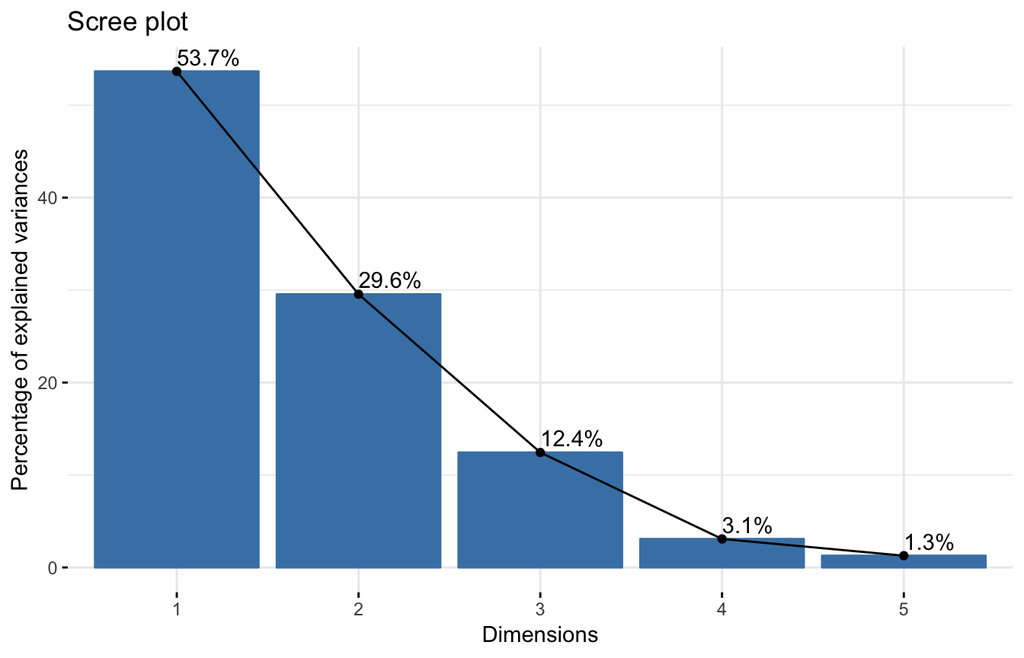

```r
fviz_eig(z, addlabels = TRUE)
```

## Mammal life history

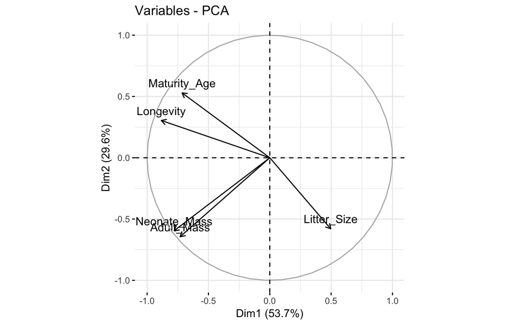

```r
fviz_pca_var(z) + coord_fixed()
```

## Mammal life history

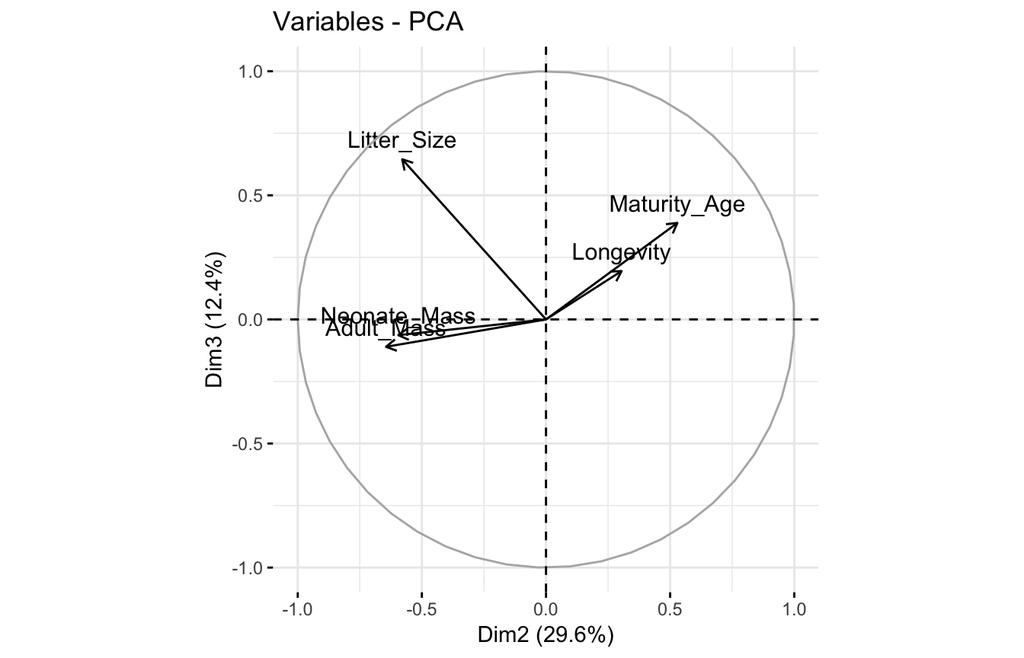

```r
fviz_pca_var(z, axes = c(2, 3)) + coord_fixed()
```

## Trilobites

[figure not shown]

## Trilobites

```r
M <- read_excel("../data/Trilobites.xlsx")
M
```

```
## # A tibble: 20 x 4
##    Genus         Body_Length Glabella_Length Glabella_Width
##    <chr>               <dbl>           <dbl>          <dbl>
##  1 Acaste               23.1            3.5            3.77
##  2 Balizoma             14.3            3.97           4.08
##  3 Calymene             51.7           10.9           10.7
##  4 Ceraurus             21.2            4.9            4.69
##  5 Cheirurus            31.7            9.33          12.1
##  6 Cybantyx             36.8           11.4           10.1
##  7 Cybeloides           25.1            6.39           6.81
##  8 Dalmanites           32.9            8.46           6.08
##  9 Deiphon              21.8            6.92           9.01
## 10 Ormathops            13.9            5.03           4.34
## 11 Phacopidina          21.4            7.03           6.79
## 12 Phacops              27.2            5.3            8.19
## 13 Placopania           38.2            9.4            8.71
## 14 Pricyclopyge         40.1           15.0           13.0
## 15 Ptychoparia          62.2           12.2            8.71
## 16 Rhenops              55.9           19             13.1
## 17 Sphaerexochus        23.3            3.84           4.6
## 18 Toxochasmops         46.1            8.15          11.4
## 19 Trimerus             89.4           23.2           21.5
## 20 Zacanthoides         47.9           13.6           11.8
```

## Trilobites

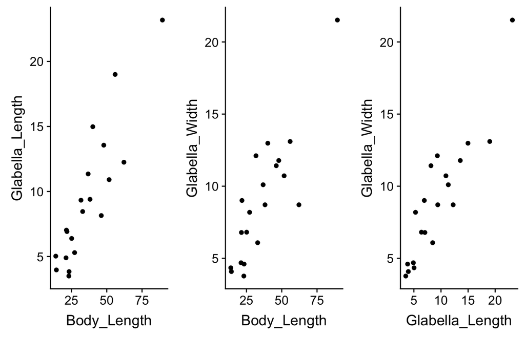

## Trilobites

```r
z <- prcomp(~ .,
            data = M,
            scale. = TRUE,
            center = TRUE)
```

## Trilobites

```r
summary(z)
```

```
## Importance of components:
##                           PC1     PC2    PC3
## Standard deviation     1.6662 0.37627 0.2867
## Proportion of Variance 0.9254 0.04719 0.0274
## Cumulative Proportion  0.9254 0.97260 1.0000
```

- PC1 accounts for about 93% of the variance

## Trilobites

```
## Standard deviations (1, .., p=3):
## [1] 1.6662015 0.3762685 0.2866962
##
## Rotation (n x k) = (3 x 3):
##                       PC1        PC2        PC3
## Body_Length     0.5727476 -0.7572887  0.3138058
## Glabella_Length 0.5834596  0.1077154 -0.8049673
## Glabella_Width  0.5757909  0.6441360  0.5035411
```

- PC1 is overall size (all load positively)
- PC2 is dominated by the negative correlation between body length and glabella width

## Sample size and other concerns

Suggested sample sizes vary:

- *n* = over 50
- *n*:*q* > 5:1 (often violated with genomic data)
- *n* and *n*:*q* are both large

All data:

- Numeric (continuous)
- No missing values

## Best case

- A small number of variables that can be used as surrogates for the larger set without too much loss of information
- Lower dimensional summary of a larger set of variables

PC1:

- Variables that combined account for the most variance
- For morphological data:
  - Can often be a proxy for “size”
  - Remaining PCs are “shape”

## Drawbacks

1. Lose the original variable identity
   - Interpretation can be a challenge
2. If centered and scaled (advised), you lose the original scale

## References

Everitt, B., and T. Hothorn. 2011. *An Introduction to Applied Multivariate Analysis with R*. Springer, New York.

Tabachnick, B. G., and L. S. Fidell. 2013. *Using Multivariate Statistics*. Pearson Education, Boston.